# Risk Factor Analysis

## Outcome Variable

**Outcome Variable:** swasted

## Predictor Variables

**Intervention Variable:** sex

**Adjustment Set:**

unadjusted

## Stratifying Variables

The analysis was stratified on these variable(s):

- agecat
- studyid
- country

## Data Summary

| agecat | studyid | country | sex | swasted | n_cell | n |
| --- | --- | --- | --- | --- | --- | --- |
| Birth | CMC-V-BCS-2002 | INDIA | Female | 0 | 43 | 86 |
| Birth | CMC-V-BCS-2002 | INDIA | Female | 1 | 0 | 86 |
| Birth | CMC-V-BCS-2002 | INDIA | Male | 0 | 42 | 86 |
| Birth | CMC-V-BCS-2002 | INDIA | Male | 1 | 1 | 86 |
| Birth | CMIN | BANGLADESH | Female | 0 | 9 | 19 |
| Birth | CMIN | BANGLADESH | Female | 1 | 0 | 19 |
| Birth | CMIN | BANGLADESH | Male | 0 | 9 | 19 |
| Birth | CMIN | BANGLADESH | Male | 1 | 1 | 19 |
| Birth | COHORTS | GUATEMALA | Female | 0 | 335 | 756 |
| Birth | COHORTS | GUATEMALA | Female | 1 | 25 | 756 |
| Birth | COHORTS | GUATEMALA | Male | 0 | 361 | 756 |
| Birth | COHORTS | GUATEMALA | Male | 1 | 35 | 756 |
| Birth | COHORTS | INDIA | Female | 0 | 2802 | 6193 |
| Birth | COHORTS | INDIA | Female | 1 | 150 | 6193 |
| Birth | COHORTS | INDIA | Male | 0 | 3071 | 6193 |
| Birth | COHORTS | INDIA | Male | 1 | 170 | 6193 |
| Birth | COHORTS | PHILIPPINES | Female | 0 | 1306 | 2899 |
| Birth | COHORTS | PHILIPPINES | Female | 1 | 54 | 2899 |
| Birth | COHORTS | PHILIPPINES | Male | 0 | 1472 | 2899 |
| Birth | COHORTS | PHILIPPINES | Male | 1 | 67 | 2899 |
| Birth | CONTENT | PERU | Female | 0 | 0 | 2 |
| Birth | CONTENT | PERU | Female | 1 | 0 | 2 |
| Birth | CONTENT | PERU | Male | 0 | 2 | 2 |
| Birth | CONTENT | PERU | Male | 1 | 0 | 2 |
| Birth | EE | PAKISTAN | Female | 0 | 87 | 177 |
| Birth | EE | PAKISTAN | Female | 1 | 1 | 177 |
| Birth | EE | PAKISTAN | Male | 0 | 84 | 177 |
| Birth | EE | PAKISTAN | Male | 1 | 5 | 177 |
| Birth | GMS-Nepal | NEPAL | Female | 0 | 283 | 641 |
| Birth | GMS-Nepal | NEPAL | Female | 1 | 14 | 641 |

[output cut: 298 more lines]

The following strata were considered:

- agecat: 24 months, studyid: CMC-V-BCS-2002, country: INDIA
- agecat: 24 months, studyid: CMIN, country: BANGLADESH
- agecat: 24 months, studyid: COHORTS, country: GUATEMALA
- agecat: 24 months, studyid: COHORTS, country: INDIA
- agecat: 24 months, studyid: COHORTS, country: PHILIPPINES
- agecat: 24 months, studyid: CONTENT, country: PERU
- agecat: 24 months, studyid: EE, country: PAKISTAN
- agecat: 24 months, studyid: GMS-Nepal, country: NEPAL
- agecat: 24 months, studyid: IRC, country: INDIA
- agecat: 24 months, studyid: JiVitA-3, country: BANGLADESH
- agecat: 24 months, studyid: JiVitA-4, country: BANGLADESH
- agecat: 24 months, studyid: Keneba, country: GAMBIA
- agecat: 24 months, studyid: LCNI-5, country: MALAWI
- agecat: 24 months, studyid: MAL-ED, country: BANGLADESH
- agecat: 24 months, studyid: MAL-ED, country: BRAZIL
- agecat: 24 months, studyid: MAL-ED, country: INDIA
- agecat: 24 months, studyid: MAL-ED, country: NEPAL
- agecat: 24 months, studyid: MAL-ED, country: PERU
- agecat: 24 months, studyid: MAL-ED, country: SOUTH AFRICA
- agecat: 24 months, studyid: MAL-ED, country: TANZANIA, UNITED REPUBLIC OF
- agecat: 24 months, studyid: NIH-Birth, country: BANGLADESH
- agecat: 24 months, studyid: NIH-Crypto, country: BANGLADESH
- agecat: 24 months, studyid: PROBIT, country: BELARUS
- agecat: 24 months, studyid: PROVIDE, country: BANGLADESH
- agecat: 24 months, studyid: TanzaniaChild2, country: TANZANIA, UNITED REPUBLIC OF
- agecat: 24 months, studyid: ZVITAMBO, country: ZIMBABWE
- agecat: 6 months, studyid: CMC-V-BCS-2002, country: INDIA
- agecat: 6 months, studyid: CMIN, country: BANGLADESH
- agecat: 6 months, studyid: COHORTS, country: GUATEMALA
- agecat: 6 months, studyid: COHORTS, country: INDIA
- agecat: 6 months, studyid: COHORTS, country: PHILIPPINES
- agecat: 6 months, studyid: CONTENT, country: PERU
- agecat: 6 months, studyid: EE, country: PAKISTAN
- agecat: 6 months, studyid: GMS-Nepal, country: NEPAL
- agecat: 6 months, studyid: Guatemala BSC, country: GUATEMALA
- agecat: 6 months, studyid: IRC, country: INDIA
- agecat: 6 months, studyid: JiVitA-3, country: BANGLADESH
- agecat: 6 months, studyid: JiVitA-4, country: BANGLADESH
- agecat: 6 months, studyid: Keneba, country: GAMBIA
- agecat: 6 months, studyid: LCNI-5, country: MALAWI
- agecat: 6 months, studyid: MAL-ED, country: BANGLADESH
- agecat: 6 months, studyid: MAL-ED, country: BRAZIL
- agecat: 6 months, studyid: MAL-ED, country: INDIA
- agecat: 6 months, studyid: MAL-ED, country: NEPAL
- agecat: 6 months, studyid: MAL-ED, country: PERU
- agecat: 6 months, studyid: MAL-ED, country: SOUTH AFRICA
- agecat: 6 months, studyid: MAL-ED, country: TANZANIA, UNITED REPUBLIC OF
- agecat: 6 months, studyid: NIH-Birth, country: BANGLADESH
- agecat: 6 months, studyid: NIH-Crypto, country: BANGLADESH
- agecat: 6 months, studyid: PROBIT, country: BELARUS
- agecat: 6 months, studyid: PROVIDE, country: BANGLADESH
- agecat: 6 months, studyid: ResPak, country: PAKISTAN
- agecat: 6 months, studyid: SAS-CompFeed, country: INDIA
- agecat: 6 months, studyid: SAS-FoodSuppl, country: INDIA
- agecat: 6 months, studyid: TanzaniaChild2, country: TANZANIA, UNITED REPUBLIC OF
- agecat: 6 months, studyid: ZVITAMBO, country: ZIMBABWE
- agecat: Birth, studyid: CMC-V-BCS-2002, country: INDIA
- agecat: Birth, studyid: CMIN, country: BANGLADESH
- agecat: Birth, studyid: COHORTS, country: GUATEMALA
- agecat: Birth, studyid: COHORTS, country: INDIA
- agecat: Birth, studyid: COHORTS, country: PHILIPPINES
- agecat: Birth, studyid: CONTENT, country: PERU
- agecat: Birth, studyid: EE, country: PAKISTAN
- agecat: Birth, studyid: GMS-Nepal, country: NEPAL
- agecat: Birth, studyid: IRC, country: INDIA
- agecat: Birth, studyid: JiVitA-3, country: BANGLADESH
- agecat: Birth, studyid: JiVitA-4, country: BANGLADESH
- agecat: Birth, studyid: Keneba, country: GAMBIA
- agecat: Birth, studyid: MAL-ED, country: BANGLADESH
- agecat: Birth, studyid: MAL-ED, country: BRAZIL
- agecat: Birth, studyid: MAL-ED, country: INDIA
- agecat: Birth, studyid: MAL-ED, country: NEPAL
- agecat: Birth, studyid: MAL-ED, country: PERU
- agecat: Birth, studyid: MAL-ED, country: SOUTH AFRICA
- agecat: Birth, studyid: MAL-ED, country: TANZANIA, UNITED REPUBLIC OF
- agecat: Birth, studyid: NIH-Birth, country: BANGLADESH
- agecat: Birth, studyid: NIH-Crypto, country: BANGLADESH
- agecat: Birth, studyid: PROBIT, country: BELARUS
- agecat: Birth, studyid: PROVIDE, country: BANGLADESH
- agecat: Birth, studyid: ResPak, country: PAKISTAN
- agecat: Birth, studyid: SAS-CompFeed, country: INDIA
- agecat: Birth, studyid: ZVITAMBO, country: ZIMBABWE

### Dropped Strata

Some strata were dropped due to rare outcomes:

- agecat: Birth, studyid: CMC-V-BCS-2002, country: INDIA
- agecat: Birth, studyid: CMIN, country: BANGLADESH
- agecat: Birth, studyid: CONTENT, country: PERU
- agecat: Birth, studyid: EE, country: PAKISTAN
- agecat: Birth, studyid: MAL-ED, country: BANGLADESH
- agecat: Birth, studyid: MAL-ED, country: BRAZIL
- agecat: Birth, studyid: MAL-ED, country: INDIA
- agecat: Birth, studyid: MAL-ED, country: NEPAL
- agecat: Birth, studyid: MAL-ED, country: PERU
- agecat: Birth, studyid: MAL-ED, country: SOUTH AFRICA
- agecat: Birth, studyid: MAL-ED, country: TANZANIA, UNITED REPUBLIC OF
- agecat: Birth, studyid: ResPak, country: PAKISTAN
- agecat: 6 months, studyid: CMIN, country: BANGLADESH
- agecat: 6 months, studyid: COHORTS, country: GUATEMALA
- agecat: 6 months, studyid: CONTENT, country: PERU
- agecat: 6 months, studyid: GMS-Nepal, country: NEPAL
- agecat: 6 months, studyid: Guatemala BSC, country: GUATEMALA
- agecat: 6 months, studyid: LCNI-5, country: MALAWI
- agecat: 6 months, studyid: MAL-ED, country: BANGLADESH
- agecat: 6 months, studyid: MAL-ED, country: BRAZIL
- agecat: 6 months, studyid: MAL-ED, country: INDIA
- agecat: 6 months, studyid: MAL-ED, country: NEPAL
- agecat: 6 months, studyid: MAL-ED, country: PERU
- agecat: 6 months, studyid: MAL-ED, country: SOUTH AFRICA
- agecat: 6 months, studyid: MAL-ED, country: TANZANIA, UNITED REPUBLIC OF
- agecat: 6 months, studyid: NIH-Birth, country: BANGLADESH
- agecat: 6 months, studyid: NIH-Crypto, country: BANGLADESH
- agecat: 6 months, studyid: PROBIT, country: BELARUS
- agecat: 6 months, studyid: PROVIDE, country: BANGLADESH
- agecat: 6 months, studyid: ResPak, country: PAKISTAN
- agecat: 6 months, studyid: TanzaniaChild2, country: TANZANIA, UNITED REPUBLIC OF
- agecat: 24 months, studyid: CMC-V-BCS-2002, country: INDIA
- agecat: 24 months, studyid: CMIN, country: BANGLADESH
- agecat: 24 months, studyid: COHORTS, country: GUATEMALA
- agecat: 24 months, studyid: CONTENT, country: PERU
- agecat: 24 months, studyid: EE, country: PAKISTAN
- agecat: 24 months, studyid: GMS-Nepal, country: NEPAL
- agecat: 24 months, studyid: IRC, country: INDIA
- agecat: 24 months, studyid: LCNI-5, country: MALAWI
- agecat: 24 months, studyid: MAL-ED, country: BANGLADESH
- agecat: 24 months, studyid: MAL-ED, country: BRAZIL
- agecat: 24 months, studyid: MAL-ED, country: INDIA
- agecat: 24 months, studyid: MAL-ED, country: NEPAL
- agecat: 24 months, studyid: MAL-ED, country: PERU
- agecat: 24 months, studyid: MAL-ED, country: SOUTH AFRICA
- agecat: 24 months, studyid: MAL-ED, country: TANZANIA, UNITED REPUBLIC OF
- agecat: 24 months, studyid: NIH-Birth, country: BANGLADESH
- agecat: 24 months, studyid: NIH-Crypto, country: BANGLADESH
- agecat: 24 months, studyid: PROBIT, country: BELARUS
- agecat: 24 months, studyid: PROVIDE, country: BANGLADESH
- agecat: 24 months, studyid: TanzaniaChild2, country: TANZANIA, UNITED REPUBLIC OF

## Methods Detail

We’re interested in the causal parameters $E[Y_a]$ for all values of $a \in \mathcal{A}$. These parameters represent the mean outcome if, possibly contrary to fact, we intervened to set all units to have $A=a$. Under the randomization and positivity assumptions, these are identified by the statistical parameters $\psi_a=E_W[E_{Y|A,W}(Y|A=a,W)]$. In addition, we’re interested in the mean of $Y$, $E[Y]$ under no intervention (the observed mean). We will estimate these parameters by using SuperLearner to fit the relevant likelihood factors – $E_{Y|A,W}(Y|A=a,W)$ and $p(A=a|W)$, and then updating our likelihood fit using a joint TMLE.

For unadjusted analyses ($W=\{\}$), initial likelihoods were estimated using Lrnr_glm to estimate the simple $E(Y|A)$ and Lrnr_mean to estimate $p(A)$. For adjusted analyses, a small library containing Lrnr_glmnet, Lrnr_xgboost, and Lrnr_mean was used.

Having estimated these parameters, we will then use the delta method to estimate relative risks and attributable risks relative to a prespecified baseline level of $A$.

# Results Detail

## Results Plots

[figure not shown]

[figure not shown]

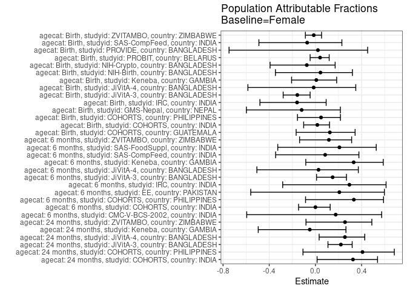

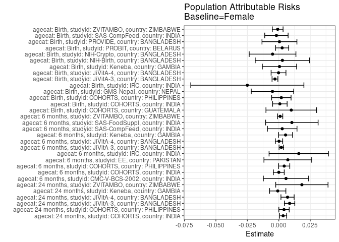

## Results Table

### Parameter: TSM

| agecat | studyid | country | intervention_level | baseline_level | estimate | ci_lower | ci_upper |
| --- | --- | --- | --- | --- | --- | --- | --- |
| Birth | COHORTS | GUATEMALA | Female | NA | 0.0694444 | 0.0431675 | 0.0957213 |
| Birth | COHORTS | GUATEMALA | Male | NA | 0.0883838 | 0.0604082 | 0.1163595 |
| Birth | COHORTS | INDIA | Female | NA | 0.0508130 | 0.0428900 | 0.0587360 |
| Birth | COHORTS | INDIA | Male | NA | 0.0524529 | 0.0447771 | 0.0601288 |
| Birth | COHORTS | PHILIPPINES | Female | NA | 0.0397059 | 0.0293262 | 0.0500855 |
| Birth | COHORTS | PHILIPPINES | Male | NA | 0.0435348 | 0.0333381 | 0.0537314 |
| Birth | GMS-Nepal | NEPAL | Female | NA | 0.0471380 | 0.0230162 | 0.0712598 |
| Birth | GMS-Nepal | NEPAL | Male | NA | 0.0377907 | 0.0176240 | 0.0579574 |
| Birth | IRC | INDIA | Female | NA | 0.1824324 | 0.1201215 | 0.2447433 |
| Birth | IRC | INDIA | Male | NA | 0.1384615 | 0.0899141 | 0.1870090 |
| Birth | JiVitA-3 | BANGLADESH | Female | NA | 0.0224073 | 0.0187074 | 0.0261073 |
| Birth | JiVitA-3 | BANGLADESH | Male | NA | 0.0166491 | 0.0138481 | 0.0194501 |
| Birth | JiVitA-4 | BANGLADESH | Female | NA | 0.0131349 | 0.0029990 | 0.0232707 |
| Birth | JiVitA-4 | BANGLADESH | Male | NA | 0.0127592 | 0.0079439 | 0.0175745 |
| Birth | Keneba | GAMBIA | Female | NA | 0.0697013 | 0.0508713 | 0.0885313 |
| Birth | Keneba | GAMBIA | Male | NA | 0.0707733 | 0.0525708 | 0.0889757 |
| Birth | NIH-Birth | BANGLADESH | Female | NA | 0.0631970 | 0.0340951 | 0.0922990 |
| Birth | NIH-Birth | BANGLADESH | Male | NA | 0.0686275 | 0.0402760 | 0.0969789 |
| Birth | NIH-Crypto | BANGLADESH | Female | NA | 0.0714286 | 0.0444285 | 0.0984287 |
| Birth | NIH-Crypto | BANGLADESH | Male | NA | 0.0616246 | 0.0366622 | 0.0865871 |
| Birth | PROBIT | BELARUS | Female | NA | 0.0638266 | 0.0298406 | 0.0978126 |
| Birth | PROBIT | BELARUS | Male | NA | 0.0690333 | 0.0358948 | 0.1021717 |
| Birth | PROVIDE | BANGLADESH | Female | NA | 0.0239044 | 0.0049895 | 0.0428193 |
| Birth | PROVIDE | BANGLADESH | Male | NA | 0.0249110 | 0.0066712 | 0.0431509 |
| Birth | SAS-CompFeed | INDIA | Female | NA | 0.0281690 | 0.0109460 | 0.0453921 |
| Birth | SAS-CompFeed | INDIA | Male | NA | 0.0247525 | 0.0092283 | 0.0402767 |
| Birth | ZVITAMBO | ZIMBABWE | Female | NA | 0.0621986 | 0.0561973 | 0.0682000 |
| Birth | ZVITAMBO | ZIMBABWE | Male | NA | 0.0604929 | 0.0547822 | 0.0662036 |
| 6 months | CMC-V-BCS-2002 | INDIA | Female | NA | 0.0268817 | 0.0036065 | 0.0501569 |
| 6 months | CMC-V-BCS-2002 | INDIA | Male | NA | 0.0384615 | 0.0104846 | 0.0664385 |
| 6 months | COHORTS | INDIA | Female | NA | 0.0316687 | 0.0256790 | 0.0376584 |
| 6 months | COHORTS | INDIA | Male | NA | 0.0316882 | 0.0259385 | 0.0374379 |
| 6 months | COHORTS | PHILIPPINES | Female | NA | 0.0086275 | 0.0035501 | 0.0137048 |
| 6 months | COHORTS | PHILIPPINES | Male | NA | 0.0167715 | 0.0101169 | 0.0234261 |
| 6 months | EE | PAKISTAN | Female | NA | 0.0274725 | 0.0036936 | 0.0512515 |
| 6 months | EE | PAKISTAN | Male | NA | 0.0414508 | 0.0132914 | 0.0696101 |
| 6 months | IRC | INDIA | Female | NA | 0.0380435 | 0.0103683 | 0.0657186 |
| 6 months | IRC | INDIA | Male | NA | 0.0669643 | 0.0341904 | 0.0997382 |
| 6 months | JiVitA-3 | BANGLADESH | Female | NA | 0.0116590 | 0.0091799 | 0.0141381 |
| 6 months | JiVitA-3 | BANGLADESH | Male | NA | 0.0156725 | 0.0127278 | 0.0186172 |
| 6 months | JiVitA-4 | BANGLADESH | Female | NA | 0.0066445 | 0.0030623 | 0.0102267 |
| 6 months | JiVitA-4 | BANGLADESH | Male | NA | 0.0070103 | 0.0023507 | 0.0116699 |
| 6 months | Keneba | GAMBIA | Female | NA | 0.0108803 | 0.0044841 | 0.0172765 |
| 6 months | Keneba | GAMBIA | Male | NA | 0.0213358 | 0.0127077 | 0.0299639 |
| 6 months | SAS-CompFeed | INDIA | Female | NA | 0.0295082 | 0.0196810 | 0.0393354 |
| 6 months | SAS-CompFeed | INDIA | Male | NA | 0.0345304 | 0.0178765 | 0.0511843 |
| 6 months | SAS-FoodSuppl | INDIA | Female | NA | 0.0396040 | 0.0126738 | 0.0665341 |
| 6 months | SAS-FoodSuppl | INDIA | Male | NA | 0.0617978 | 0.0263781 | 0.0972175 |
| 6 months | ZVITAMBO | ZIMBABWE | Female | NA | 0.0082046 | 0.0054580 | 0.0109513 |
| 6 months | ZVITAMBO | ZIMBABWE | Male | NA | 0.0103187 | 0.0073193 | 0.0133182 |
| 24 months | COHORTS | INDIA | Female | NA | 0.0071400 | 0.0038530 | 0.0104270 |
| 24 months | COHORTS | INDIA | Male | NA | 0.0137184 | 0.0093863 | 0.0180505 |
| 24 months | COHORTS | PHILIPPINES | Female | NA | 0.0060449 | 0.0015795 | 0.0105103 |
| 24 months | COHORTS | PHILIPPINES | Male | NA | 0.0139427 | 0.0075454 | 0.0203400 |
| 24 months | JiVitA-3 | BANGLADESH | Female | NA | 0.0303468 | 0.0249460 | 0.0357477 |
| 24 months | JiVitA-3 | BANGLADESH | Male | NA | 0.0469557 | 0.0406332 | 0.0532783 |
| 24 months | JiVitA-4 | BANGLADESH | Female | NA | 0.0202788 | 0.0131621 | 0.0273956 |
| 24 months | JiVitA-4 | BANGLADESH | Male | NA | 0.0342061 | 0.0265266 | 0.0418855 |
| 24 months | Keneba | GAMBIA | Female | NA | 0.0182260 | 0.0090843 | 0.0273677 |
| 24 months | Keneba | GAMBIA | Male | NA | 0.0166113 | 0.0082727 | 0.0249499 |
| 24 months | ZVITAMBO | ZIMBABWE | Female | NA | 0.0532319 | 0.0260688 | 0.0803951 |
| 24 months | ZVITAMBO | ZIMBABWE | Male | NA | 0.1000000 | 0.0548511 | 0.1451489 |

### Parameter: E(Y)

| agecat | studyid | country | intervention_level | baseline_level | estimate | ci_lower | ci_upper |
| --- | --- | --- | --- | --- | --- | --- | --- |
| Birth | COHORTS | GUATEMALA | NA | NA | 0.0793651 | 0.0600839 | 0.0986462 |
| Birth | COHORTS | INDIA | NA | NA | 0.0516712 | 0.0461576 | 0.0571849 |
| Birth | COHORTS | PHILIPPINES | NA | NA | 0.0417385 | 0.0344572 | 0.0490198 |
| Birth | GMS-Nepal | NEPAL | NA | NA | 0.0421217 | 0.0265597 | 0.0576837 |
| Birth | IRC | INDIA | NA | NA | 0.1574344 | 0.1188345 | 0.1960344 |
| Birth | JiVitA-3 | BANGLADESH | NA | NA | 0.0193738 | 0.0169653 | 0.0217823 |
| Birth | JiVitA-4 | BANGLADESH | NA | NA | 0.0129382 | 0.0075150 | 0.0183614 |
| Birth | Keneba | GAMBIA | NA | NA | 0.0702592 | 0.0571716 | 0.0833469 |
| Birth | NIH-Birth | BANGLADESH | NA | NA | 0.0660870 | 0.0457632 | 0.0864107 |
| Birth | NIH-Crypto | BANGLADESH | NA | NA | 0.0664781 | 0.0481022 | 0.0848539 |
| Birth | PROBIT | BELARUS | NA | NA | 0.0665123 | 0.0333611 | 0.0996634 |
| Birth | PROVIDE | BANGLADESH | NA | NA | 0.0244361 | 0.0113037 | 0.0375685 |
| Birth | SAS-CompFeed | INDIA | NA | NA | 0.0262919 | 0.0122874 | 0.0402964 |
| Birth | ZVITAMBO | ZIMBABWE | NA | NA | 0.0613145 | 0.0571772 | 0.0654519 |
| 6 months | CMC-V-BCS-2002 | INDIA | NA | NA | 0.0326087 | 0.0144375 | 0.0507799 |
| 6 months | COHORTS | INDIA | NA | NA | 0.0316788 | 0.0275309 | 0.0358267 |
| 6 months | COHORTS | PHILIPPINES | NA | NA | 0.0129342 | 0.0086762 | 0.0171922 |
| 6 months | EE | PAKISTAN | NA | NA | 0.0346667 | 0.0161268 | 0.0532065 |
| 6 months | IRC | INDIA | NA | NA | 0.0539216 | 0.0319786 | 0.0758646 |
| 6 months | JiVitA-3 | BANGLADESH | NA | NA | 0.0137035 | 0.0116269 | 0.0157801 |
| 6 months | JiVitA-4 | BANGLADESH | NA | NA | 0.0068281 | 0.0038634 | 0.0097927 |
| 6 months | Keneba | GAMBIA | NA | NA | 0.0162757 | 0.0108484 | 0.0217031 |
| 6 months | SAS-CompFeed | INDIA | NA | NA | 0.0322339 | 0.0235219 | 0.0409459 |
| 6 months | SAS-FoodSuppl | INDIA | NA | NA | 0.0500000 | 0.0280580 | 0.0719420 |
| 6 months | ZVITAMBO | ZIMBABWE | NA | NA | 0.0092887 | 0.0072498 | 0.0113275 |
| 24 months | COHORTS | INDIA | NA | NA | 0.0105840 | 0.0078264 | 0.0133416 |
| 24 months | COHORTS | PHILIPPINES | NA | NA | 0.0102082 | 0.0062264 | 0.0141901 |
| 24 months | JiVitA-3 | BANGLADESH | NA | NA | 0.0389399 | 0.0346167 | 0.0432631 |
| 24 months | JiVitA-4 | BANGLADESH | NA | NA | 0.0272439 | 0.0220352 | 0.0324527 |
| 24 months | Keneba | GAMBIA | NA | NA | 0.0173812 | 0.0112141 | 0.0235484 |
| 24 months | ZVITAMBO | ZIMBABWE | NA | NA | 0.0715935 | 0.0472820 | 0.0959051 |

### Parameter: RR

| agecat | studyid | country | intervention_level | baseline_level | estimate | ci_lower | ci_upper |
| --- | --- | --- | --- | --- | --- | --- | --- |
| Birth | COHORTS | GUATEMALA | Female | Female | 1.0000000 | 1.0000000 | 1.0000000 |
| Birth | COHORTS | GUATEMALA | Male | Female | 1.2727273 | 0.7771218 | 2.0844026 |
| Birth | COHORTS | INDIA | Female | Female | 1.0000000 | 1.0000000 | 1.0000000 |
| Birth | COHORTS | INDIA | Male | Female | 1.0322740 | 0.8335385 | 1.2783928 |
| Birth | COHORTS | PHILIPPINES | Female | Female | 1.0000000 | 1.0000000 | 1.0000000 |
| Birth | COHORTS | PHILIPPINES | Male | Female | 1.0964311 | 0.7718761 | 1.5574535 |
| Birth | GMS-Nepal | NEPAL | Female | Female | 1.0000000 | 1.0000000 | 1.0000000 |
| Birth | GMS-Nepal | NEPAL | Male | Female | 0.8017027 | 0.3827522 | 1.6792251 |
| Birth | IRC | INDIA | Female | Female | 1.0000000 | 1.0000000 | 1.0000000 |
| Birth | IRC | INDIA | Male | Female | 0.7589744 | 0.4652073 | 1.2382481 |
| Birth | JiVitA-3 | BANGLADESH | Female | Female | 1.0000000 | 1.0000000 | 1.0000000 |
| Birth | JiVitA-3 | BANGLADESH | Male | Female | 0.7430208 | 0.5947269 | 0.9282913 |
| Birth | JiVitA-4 | BANGLADESH | Female | Female | 1.0000000 | 1.0000000 | 1.0000000 |
| Birth | JiVitA-4 | BANGLADESH | Male | Female | 0.9713982 | 0.4098397 | 2.3023988 |
| Birth | Keneba | GAMBIA | Female | Female | 1.0000000 | 1.0000000 | 1.0000000 |
| Birth | Keneba | GAMBIA | Male | Female | 1.0153797 | 0.6992547 | 1.4744211 |
| Birth | NIH-Birth | BANGLADESH | Female | Female | 1.0000000 | 1.0000000 | 1.0000000 |
| Birth | NIH-Birth | BANGLADESH | Male | Female | 1.0859285 | 0.5849592 | 2.0159367 |
| Birth | NIH-Crypto | BANGLADESH | Female | Female | 1.0000000 | 1.0000000 | 1.0000000 |
| Birth | NIH-Crypto | BANGLADESH | Male | Female | 0.8627451 | 0.4957501 | 1.5014198 |
| Birth | PROBIT | BELARUS | Female | Female | 1.0000000 | 1.0000000 | 1.0000000 |
| Birth | PROBIT | BELARUS | Male | Female | 1.0815749 | 0.9213102 | 1.2697181 |
| Birth | PROVIDE | BANGLADESH | Female | Female | 1.0000000 | 1.0000000 | 1.0000000 |
| Birth | PROVIDE | BANGLADESH | Male | Female | 1.0421115 | 0.3545805 | 3.0627639 |
| Birth | SAS-CompFeed | INDIA | Female | Female | 1.0000000 | 1.0000000 | 1.0000000 |
| Birth | SAS-CompFeed | INDIA | Male | Female | 0.8787129 | 0.4648178 | 1.6611592 |
| Birth | ZVITAMBO | ZIMBABWE | Female | Female | 1.0000000 | 1.0000000 | 1.0000000 |
| Birth | ZVITAMBO | ZIMBABWE | Male | Female | 0.9725759 | 0.8497658 | 1.1131347 |
| 6 months | CMC-V-BCS-2002 | INDIA | Female | Female | 1.0000000 | 1.0000000 | 1.0000000 |
| 6 months | CMC-V-BCS-2002 | INDIA | Male | Female | 1.4307692 | 0.4618005 | 4.4328677 |
| 6 months | COHORTS | INDIA | Female | Female | 1.0000000 | 1.0000000 | 1.0000000 |
| 6 months | COHORTS | INDIA | Male | Female | 1.0006148 | 0.7699087 | 1.3004529 |
| 6 months | COHORTS | PHILIPPINES | Female | Female | 1.0000000 | 1.0000000 | 1.0000000 |
| 6 months | COHORTS | PHILIPPINES | Male | Female | 1.9439680 | 0.9559607 | 3.9531036 |
| 6 months | EE | PAKISTAN | Female | Female | 1.0000000 | 1.0000000 | 1.0000000 |
| 6 months | EE | PAKISTAN | Male | Female | 1.5088083 | 0.5020808 | 4.5341359 |
| 6 months | IRC | INDIA | Female | Female | 1.0000000 | 1.0000000 | 1.0000000 |
| 6 months | IRC | INDIA | Male | Female | 1.7602041 | 0.7324610 | 4.2300116 |
| 6 months | JiVitA-3 | BANGLADESH | Female | Female | 1.0000000 | 1.0000000 | 1.0000000 |
| 6 months | JiVitA-3 | BANGLADESH | Male | Female | 1.3442446 | 1.0360230 | 1.7441637 |
| 6 months | JiVitA-4 | BANGLADESH | Female | Female | 1.0000000 | 1.0000000 | 1.0000000 |
| 6 months | JiVitA-4 | BANGLADESH | Male | Female | 1.0550515 | 0.4514153 | 2.4658754 |
| 6 months | Keneba | GAMBIA | Female | Female | 1.0000000 | 1.0000000 | 1.0000000 |
| 6 months | Keneba | GAMBIA | Male | Female | 1.9609546 | 0.9606954 | 4.0026662 |
| 6 months | SAS-CompFeed | INDIA | Female | Female | 1.0000000 | 1.0000000 | 1.0000000 |
| 6 months | SAS-CompFeed | INDIA | Male | Female | 1.1701964 | 0.6021138 | 2.2742540 |
| 6 months | SAS-FoodSuppl | INDIA | Female | Female | 1.0000000 | 1.0000000 | 1.0000000 |
| 6 months | SAS-FoodSuppl | INDIA | Male | Female | 1.5603933 | 0.6412208 | 3.7971743 |
| 6 months | ZVITAMBO | ZIMBABWE | Female | Female | 1.0000000 | 1.0000000 | 1.0000000 |
| 6 months | ZVITAMBO | ZIMBABWE | Male | Female | 1.2576716 | 0.8072721 | 1.9593616 |
| 24 months | COHORTS | INDIA | Female | Female | 1.0000000 | 1.0000000 | 1.0000000 |
| 24 months | COHORTS | INDIA | Male | Female | 1.9213398 | 1.0993985 | 3.3577875 |
| 24 months | COHORTS | PHILIPPINES | Female | Female | 1.0000000 | 1.0000000 | 1.0000000 |
| 24 months | COHORTS | PHILIPPINES | Male | Female | 2.3065176 | 0.9667024 | 5.5032691 |
| 24 months | JiVitA-3 | BANGLADESH | Female | Female | 1.0000000 | 1.0000000 | 1.0000000 |
| 24 months | JiVitA-3 | BANGLADESH | Male | Female | 1.5473034 | 1.2479214 | 1.9185086 |
| 24 months | JiVitA-4 | BANGLADESH | Female | Female | 1.0000000 | 1.0000000 | 1.0000000 |
| 24 months | JiVitA-4 | BANGLADESH | Male | Female | 1.6867874 | 1.1105597 | 2.5619980 |
| 24 months | Keneba | GAMBIA | Female | Female | 1.0000000 | 1.0000000 | 1.0000000 |
| 24 months | Keneba | GAMBIA | Male | Female | 0.9114064 | 0.4482567 | 1.8530936 |
| 24 months | ZVITAMBO | ZIMBABWE | Female | Female | 1.0000000 | 1.0000000 | 1.0000000 |
| 24 months | ZVITAMBO | ZIMBABWE | Male | Female | 1.8785714 | 0.9504398 | 3.7130503 |

### Parameter: PAR

| agecat | studyid | country | intervention_level | baseline_level | estimate | ci_lower | ci_upper |
| --- | --- | --- | --- | --- | --- | --- | --- |
| Birth | COHORTS | GUATEMALA | Female | NA | 0.0099206 | -0.0101951 | 0.0300364 |
| Birth | COHORTS | INDIA | Female | NA | 0.0008582 | -0.0049149 | 0.0066314 |
| Birth | COHORTS | PHILIPPINES | Female | NA | 0.0020326 | -0.0056920 | 0.0097573 |
| Birth | GMS-Nepal | NEPAL | Female | NA | -0.0050164 | -0.0218936 | 0.0118609 |
| Birth | IRC | INDIA | Female | NA | -0.0249980 | -0.0699645 | 0.0199684 |
| Birth | JiVitA-3 | BANGLADESH | Female | NA | -0.0030335 | -0.0053469 | -0.0007201 |
| Birth | JiVitA-4 | BANGLADESH | Female | NA | -0.0001966 | -0.0060961 | 0.0057028 |
| Birth | Keneba | GAMBIA | Female | NA | 0.0005579 | -0.0130729 | 0.0141887 |
| Birth | NIH-Birth | BANGLADESH | Female | NA | 0.0028899 | -0.0187330 | 0.0245129 |
| Birth | NIH-Crypto | BANGLADESH | Female | NA | -0.0049505 | -0.0235217 | 0.0136207 |
| Birth | PROBIT | BELARUS | Female | NA | 0.0026857 | -0.0025233 | 0.0078946 |
| Birth | PROVIDE | BANGLADESH | Female | NA | 0.0005317 | -0.0133476 | 0.0144110 |
| Birth | SAS-CompFeed | INDIA | Female | NA | -0.0018771 | -0.0111600 | 0.0074058 |
| Birth | ZVITAMBO | ZIMBABWE | Female | NA | -0.0008841 | -0.0051779 | 0.0034097 |
| 6 months | CMC-V-BCS-2002 | INDIA | Female | NA | 0.0057270 | -0.0122814 | 0.0237354 |
| 6 months | COHORTS | INDIA | Female | NA | 0.0000101 | -0.0043121 | 0.0043324 |
| 6 months | COHORTS | PHILIPPINES | Female | NA | 0.0043068 | -0.0001223 | 0.0087359 |
| 6 months | EE | PAKISTAN | Female | NA | 0.0071941 | -0.0117878 | 0.0261761 |
| 6 months | IRC | INDIA | Female | NA | 0.0158781 | -0.0077139 | 0.0394701 |
| 6 months | JiVitA-3 | BANGLADESH | Female | NA | 0.0020446 | 0.0002440 | 0.0038451 |
| 6 months | JiVitA-4 | BANGLADESH | Female | NA | 0.0001835 | -0.0027424 | 0.0031094 |
| 6 months | Keneba | GAMBIA | Female | NA | 0.0053954 | -0.0001515 | 0.0109424 |
| 6 months | SAS-CompFeed | INDIA | Female | NA | 0.0027257 | -0.0090250 | 0.0144763 |
| 6 months | SAS-FoodSuppl | INDIA | Female | NA | 0.0103960 | -0.0104761 | 0.0312682 |
| 6 months | ZVITAMBO | ZIMBABWE | Female | NA | 0.0010840 | -0.0010015 | 0.0031695 |
| 24 months | COHORTS | INDIA | Female | NA | 0.0034440 | 0.0005957 | 0.0062923 |
| 24 months | COHORTS | PHILIPPINES | Female | NA | 0.0041633 | 0.0000477 | 0.0082790 |
| 24 months | JiVitA-3 | BANGLADESH | Female | NA | 0.0085931 | 0.0044526 | 0.0127336 |
| 24 months | JiVitA-4 | BANGLADESH | Female | NA | 0.0069651 | 0.0017170 | 0.0122132 |
| 24 months | Keneba | GAMBIA | Female | NA | -0.0008448 | -0.0073184 | 0.0056288 |
| 24 months | ZVITAMBO | ZIMBABWE | Female | NA | 0.0183616 | -0.0024369 | 0.0391601 |

### Parameter: PAF

| agecat | studyid | country | intervention_level | baseline_level | estimate | ci_lower | ci_upper |
| --- | --- | --- | --- | --- | --- | --- | --- |
| Birth | COHORTS | GUATEMALA | Female | NA | 0.1250000 | -0.1669159 | 0.3438902 |
| Birth | COHORTS | INDIA | Female | NA | 0.0166095 | -0.1016995 | 0.1222135 |
| Birth | COHORTS | PHILIPPINES | Female | NA | 0.0486996 | -0.1553838 | 0.2167343 |
| Birth | GMS-Nepal | NEPAL | Female | NA | -0.1190922 | -0.5977626 | 0.2161744 |
| Birth | IRC | INDIA | Female | NA | -0.1587838 | -0.4807551 | 0.0931790 |
| Birth | JiVitA-3 | BANGLADESH | Female | NA | -0.1565773 | -0.2791771 | -0.0457277 |
| Birth | JiVitA-4 | BANGLADESH | Female | NA | -0.0151969 | -0.5848296 | 0.3496937 |
| Birth | Keneba | GAMBIA | Female | NA | 0.0079410 | -0.2063298 | 0.1841526 |
| Birth | NIH-Birth | BANGLADESH | Female | NA | 0.0437292 | -0.3460671 | 0.3206476 |
| Birth | NIH-Crypto | BANGLADESH | Female | NA | -0.0744681 | -0.3926717 | 0.1710310 |
| Birth | PROBIT | BELARUS | Female | NA | 0.0403784 | -0.0457458 | 0.1194098 |
| Birth | PROVIDE | BANGLADESH | Female | NA | 0.0217591 | -0.7480517 | 0.4525590 |
| Birth | SAS-CompFeed | INDIA | Female | NA | -0.0713939 | -0.4895273 | 0.2293630 |
| Birth | ZVITAMBO | ZIMBABWE | Female | NA | -0.0144191 | -0.0869158 | 0.0532421 |
| 6 months | CMC-V-BCS-2002 | INDIA | Female | NA | 0.1756272 | -0.5948362 | 0.5738807 |
| 6 months | COHORTS | INDIA | Female | NA | 0.0003199 | -0.1458700 | 0.1278590 |
| 6 months | COHORTS | PHILIPPINES | Female | NA | 0.3329748 | -0.0853646 | 0.5900708 |
| 6 months | EE | PAKISTAN | Female | NA | 0.2075232 | -0.5602287 | 0.5974825 |
| 6 months | IRC | INDIA | Female | NA | 0.2944664 | -0.2834635 | 0.6121606 |
| 6 months | JiVitA-3 | BANGLADESH | Female | NA | 0.1491990 | 0.0098353 | 0.2689475 |
| 6 months | JiVitA-4 | BANGLADESH | Female | NA | 0.0268801 | -0.5070136 | 0.3716299 |
| 6 months | Keneba | GAMBIA | Female | NA | 0.3315006 | -0.0834585 | 0.5875324 |
| 6 months | SAS-CompFeed | INDIA | Female | NA | 0.0845597 | -0.3445988 | 0.3767427 |
| 6 months | SAS-FoodSuppl | INDIA | Female | NA | 0.2079208 | -0.3261206 | 0.5268986 |
| 6 months | ZVITAMBO | ZIMBABWE | Female | NA | 0.1167037 | -0.1370781 | 0.3138446 |
| 24 months | COHORTS | INDIA | Female | NA | 0.3253953 | 0.0146092 | 0.5381613 |
| 24 months | COHORTS | PHILIPPINES | Female | NA | 0.4078411 | -0.1077391 | 0.6834524 |
| 24 months | JiVitA-3 | BANGLADESH | Female | NA | 0.2206755 | 0.1087567 | 0.3185400 |
| 24 months | JiVitA-4 | BANGLADESH | Female | NA | 0.2556568 | 0.0324446 | 0.4273745 |
| 24 months | Keneba | GAMBIA | Female | NA | -0.0486027 | -0.4952249 | 0.2646139 |
| 24 months | ZVITAMBO | ZIMBABWE | Female | NA | 0.2564700 | -0.0816655 | 0.4889022 |